# Semana6

Juan Felipe Ladino

3 de marzo de 2020

## Algunos algoritmos de machine learning

```r
library(readxl)
default <- read_excel("C:/Users/juanf/Desktop/2020-1/BigData-UR-2020-1/Semana 6 - Naive Bayes, DT, Random Forest/default of credit card clients.xls")
```

```r
str(default)
```

```
## Classes 'tbl_df', 'tbl' and 'data.frame':    30000 obs. of  25 variables:
##  $ ID                        : num  1 2 3 4 5 6 7 8 9 10 ...
##  $ LIMIT_BAL                 : num  20000 120000 90000 50000 50000 50000 500000 100000 140000 20000 ...
##  $ SEX                       : num  2 2 2 2 1 1 1 2 2 1 ...
##  $ EDUCATION                 : num  2 2 2 2 2 1 1 2 3 3 ...
##  $ MARRIAGE                  : num  1 2 2 1 1 2 2 2 1 2 ...
##  $ AGE                       : num  24 26 34 37 57 37 29 23 28 35 ...
##  $ PAY_0                     : num  2 -1 0 0 -1 0 0 0 0 -2 ...
##  $ PAY_2                     : num  2 2 0 0 0 0 0 -1 0 -2 ...
##  $ PAY_3                     : num  -1 0 0 0 -1 0 0 -1 2 -2 ...
##  $ PAY_4                     : num  -1 0 0 0 0 0 0 0 0 -2 ...
##  $ PAY_5                     : num  -2 0 0 0 0 0 0 0 0 -1 ...
##  $ PAY_6                     : num  -2 2 0 0 0 0 0 -1 0 -1 ...
##  $ BILL_AMT1                 : num  3913 2682 29239 46990 8617 ...
##  $ BILL_AMT2                 : num  3102 1725 14027 48233 5670 ...
##  $ BILL_AMT3                 : num  689 2682 13559 49291 35835 ...
##  $ BILL_AMT4                 : num  0 3272 14331 28314 20940 ...
##  $ BILL_AMT5                 : num  0 3455 14948 28959 19146 ...
##  $ BILL_AMT6                 : num  0 3261 15549 29547 19131 ...
##  $ PAY_AMT1                  : num  0 0 1518 2000 2000 ...
##  $ PAY_AMT2                  : num  689 1000 1500 2019 36681 ...
##  $ PAY_AMT3                  : num  0 1000 1000 1200 10000 657 38000 0 432 0 ...
##  $ PAY_AMT4                  : num  0 1000 1000 1100 9000 ...
##  $ PAY_AMT5                  : num  0 0 1000 1069 689 ...
##  $ PAY_AMT6                  : num  0 2000 5000 1000 679 ...
##  $ default payment next month: num  1 1 0 0 0 0 0 0 0 0 ...
```

- Noten que la estructura de la base parece un dataframe pero no lo es. Esta estructura (tibble) no la estudiaremos. Básicamente, es otra forma de representar datos de manera estructurada. Queda para ustedes entender como funciona. Para fin de la clase, trabajemos con dataframes

```r
default <- as.data.frame(default)
```

- Podemos convertir en factores la variables que toman valores discretos, incluyendo nuestra variable de interes:

```r
default$`default payment next month` <- as.factor(default$`default payment next month`)
default$SEX <- as.factor(default$SEX)
default$EDUCATION <- as.factor(default$EDUCATION)
default$MARRIAGE <- as.factor(default$MARRIAGE)
```

- Primera tarea, automaticen el codigo de arriba.
- Exploremos nuevamente la estructura de la base:

```r
str(default)
```

```
## 'data.frame':    30000 obs. of  25 variables:
##  $ ID                        : num  1 2 3 4 5 6 7 8 9 10 ...
##  $ LIMIT_BAL                 : num  20000 120000 90000 50000 50000 50000 500000 100000 140000 20000 ...
##  $ SEX                       : Factor w/ 2 levels "1","2": 2 2 2 2 1 1 1 2 2 1 ...
##  $ EDUCATION                 : Factor w/ 7 levels "0","1","2","3",..: 3 3 3 3 3 2 2 3 4 4 ...
##  $ MARRIAGE                  : Factor w/ 4 levels "0","1","2","3": 2 3 3 2 2 3 3 3 2 3 ...
##  $ AGE                       : num  24 26 34 37 57 37 29 23 28 35 ...
##  $ PAY_0                     : num  2 -1 0 0 -1 0 0 0 0 -2 ...
##  $ PAY_2                     : num  2 2 0 0 0 0 0 -1 0 -2 ...
##  $ PAY_3                     : num  -1 0 0 0 -1 0 0 -1 2 -2 ...
##  $ PAY_4                     : num  -1 0 0 0 0 0 0 0 0 -2 ...
##  $ PAY_5                     : num  -2 0 0 0 0 0 0 0 0 -1 ...
##  $ PAY_6                     : num  -2 2 0 0 0 0 0 -1 0 -1 ...
##  $ BILL_AMT1                 : num  3913 2682 29239 46990 8617 ...
##  $ BILL_AMT2                 : num  3102 1725 14027 48233 5670 ...
##  $ BILL_AMT3                 : num  689 2682 13559 49291 35835 ...
##  $ BILL_AMT4                 : num  0 3272 14331 28314 20940 ...
##  $ BILL_AMT5                 : num  0 3455 14948 28959 19146 ...
##  $ BILL_AMT6                 : num  0 3261 15549 29547 19131 ...
##  $ PAY_AMT1                  : num  0 0 1518 2000 2000 ...
##  $ PAY_AMT2                  : num  689 1000 1500 2019 36681 ...
##  $ PAY_AMT3                  : num  0 1000 1000 1200 10000 657 38000 0 432 0 ...
##  $ PAY_AMT4                  : num  0 1000 1000 1100 9000 ...
##  $ PAY_AMT5                  : num  0 0 1000 1069 689 ...
##  $ PAY_AMT6                  : num  0 2000 5000 1000 679 ...
##  $ default payment next month: Factor w/ 2 levels "0","1": 2 2 1 1 1 1 1 1 1 1 ...
```

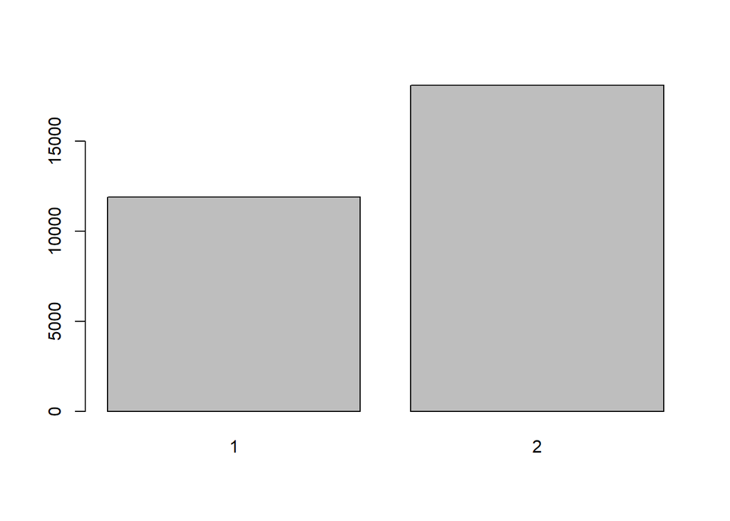

```r
plot(as.factor(default[, 3]))
```

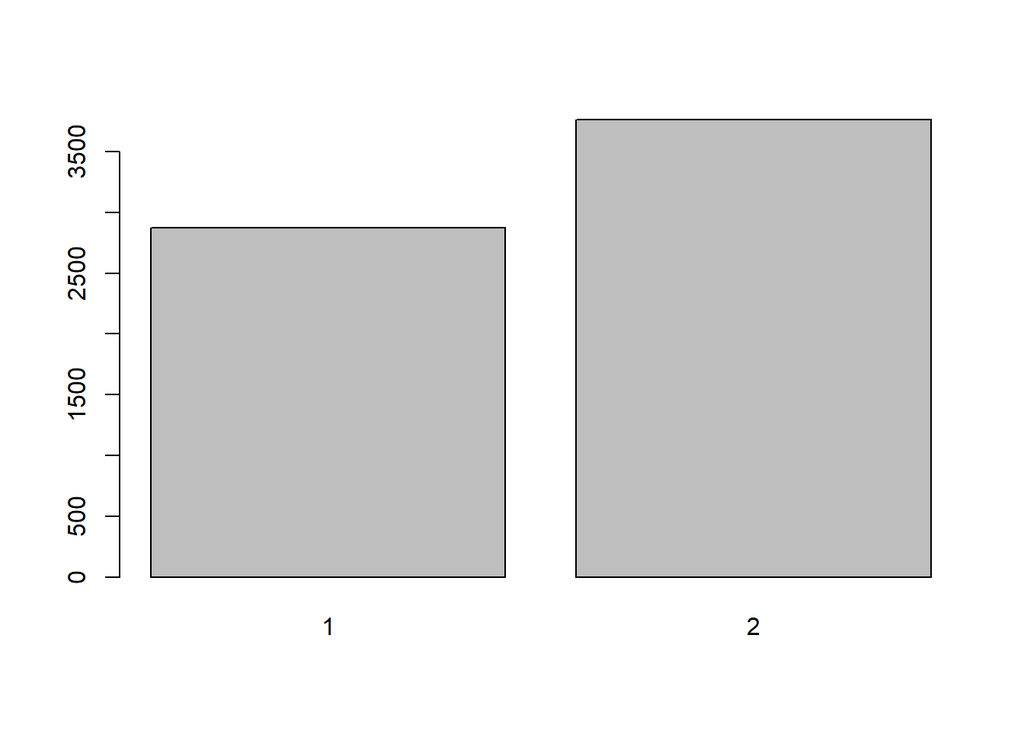

```r
plot(as.factor(default[default$`default payment next month` == 1, 3]))
```

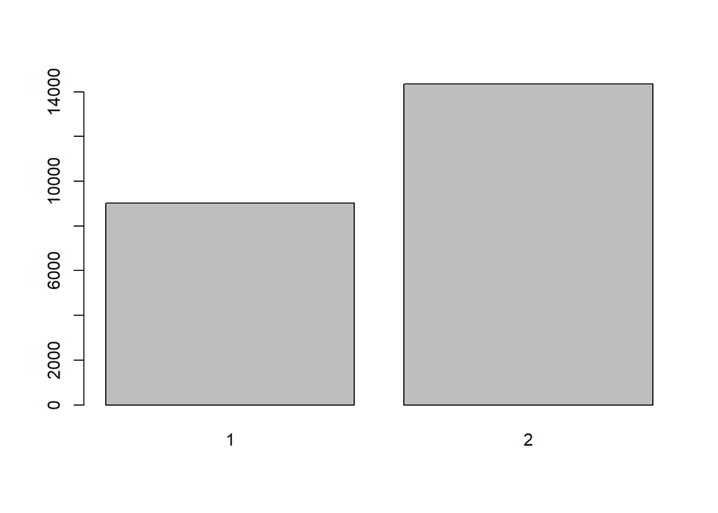

```r
plot(as.factor(default[default$`default payment next month` == 0, 3]))
```

```r
set.seed(123)
```

```r
default <- default[,-1]
```

```r
train_sample <- sample(30000,30000*0.8 )
train_sample[1:100]
```

```
##   [1]  8628 23649 12269 26488 28211  1367 15840 26767 16539 13695 28696
##  [12] 13596 20319 17172  3087 26982  7379  1262  9832 28617 26669 20770
##  [23] 19202 29806 19656 21239 16308 17809  8667  4410 28862 27042 20700
##  [34] 23838   738 14318 22727  6485  9534  6940  4279 12420 12395 11050
##  [45]  4567  4158  6981 13957  7967 25693  1373 13244 23927  3651 16799
##  [56]  6185  3819 22557 26800 11212 19914  2840 11496  8215 24388 13427
##  [67] 24249 24318 23777 13165 22582 18832 21255    19 14225  6588 11366
##  [78] 18336 10527  3326  7290 19988 12496 23581  3078 13010 29465 26714
##  [89] 26517  5236  3910 19534 10274 19642  9582  5613 23394  2799 13958
## [100] 15295
```

```r
default_train <- default[train_sample, ]
default_test <- default[-train_sample, ]
```

```r
default_train_labels <- default_train$`default payment next month`
```

```r
default_test_labels <- default_test$`default payment next month`
```

```r
default_train <- default_train[,-24]
default_test <- default_test[,-24]
```

### Naive Bayes

- Naive bayes requiere que todas las variables esten definidas como categorias. En ese sentido, hacen falta variables que debemos categorizar.
- La forma de hacer este proceso depende del conocimiento de los datos, deben explorar su distribucion o definir una categorizacion con base en algun criterio. Para fines de este ejemplo utilizaremos la media.
- Se definira como 1 a una observacion que esta por encima de la media de la variable. Asi se generan valores de 1 y 0 a partir de la condicion de ser mayor a la media. Una vez categorizada la pueden usar en el analisis.

```r
default_nb <- default
default_nb$PAY_AMT1 <- as.factor(ifelse(default_nb$PAY_AMT1 >= mean(default_nb$PAY_AMT1), 1, 0))
default_nb$PAY_AMT2 <- as.factor(ifelse(default_nb$PAY_AMT2 >= mean(default_nb$PAY_AMT2), 1, 0))
default_nb$PAY_AMT3 <- as.factor(ifelse(default_nb$PAY_AMT3 >= mean(default_nb$PAY_AMT3), 1, 0))
default_nb$PAY_AMT4 <- as.factor(ifelse(default_nb$PAY_AMT4 >= mean(default_nb$PAY_AMT4), 1, 0))
default_nb$PAY_AMT5 <- as.factor(ifelse(default_nb$PAY_AMT5 >= mean(default_nb$PAY_AMT5), 1, 0))
default_nb$PAY_AMT6 <- as.factor(ifelse(default_nb$PAY_AMT6 >= mean(default_nb$PAY_AMT6), 1, 0))
default_nb$BILL_AMT1 <- as.factor(ifelse(default_nb$BILL_AMT1 >= mean(default_nb$BILL_AMT1), 1, 0))
default_nb$BILL_AMT2 <- as.factor(ifelse(default_nb$BILL_AMT2 >= mean(default_nb$BILL_AMT2), 1, 0))
default_nb$BILL_AMT3 <- as.factor(ifelse(default_nb$BILL_AMT3 >= mean(default_nb$BILL_AMT3), 1, 0))
default_nb$BILL_AMT4 <- as.factor(ifelse(default_nb$BILL_AMT4 >= mean(default_nb$BILL_AMT4), 1, 0))
default_nb$BILL_AMT5 <- as.factor(ifelse(default_nb$BILL_AMT5 >= mean(default_nb$BILL_AMT5), 1, 0))
default_nb$BILL_AMT6 <- as.factor(ifelse(default_nb$BILL_AMT6 >= mean(default_nb$BILL_AMT6), 1, 0))
default_nb$LIMIT_BAL <- as.factor(ifelse(default_nb$LIMIT_BAL >= mean(default_nb$LIMIT_BAL), 1, 0))
default_nb$AGE <- as.factor(ifelse(default_nb$AGE >= mean(default_nb$AGE), 1, 0))
```

- Tarea, automaticen la categorizacion.
- Para los dias de pago definiremos como 1 si la variable es mayor a 0:

```r
default_nb$PAY_0 <- as.factor(ifelse(default_nb$PAY_0 > 0, 1, 0))
default_nb$PAY_2 <- as.factor(ifelse(default_nb$PAY_2 > 0, 1, 0))
default_nb$PAY_3 <- as.factor(ifelse(default_nb$PAY_3 > 0, 1, 0))
default_nb$PAY_4 <- as.factor(ifelse(default_nb$PAY_4 > 0, 1, 0))
default_nb$PAY_5 <- as.factor(ifelse(default_nb$PAY_5 > 0, 1, 0))
default_nb$PAY_6 <- as.factor(ifelse(default_nb$PAY_6 > 0, 1, 0))
```

- Una vez con todas las variables categorizadas, podemos continuar con la implementacion del Naive Bayes.
- Con la nueva base definimos el train y test (los labels no han cambiado)

```r
default_train_nb <- default_nb[train_sample, ]
default_test_nb <- default_nb[-train_sample, ]
```

```r
#install.packages("e1071")
library(e1071)
nb_classifier <- naiveBayes(default_train_nb, default_train_labels)
```

```r
nb_test_pred <- predict(nb_classifier, default_test_nb)
```

```r
library(gmodels)
```

```r
CrossTable(nb_test_pred, default_test_labels, prop.chisq=FALSE,
prop.r=FALSE, prop.c=FALSE, dnn=c('predicted', 'actual'))
```

```
##
##
##    Cell Contents
## |-------------------------|
## |                       N |
## |         N / Table Total |
## |-------------------------|
##
##
## Total Observations in Table:  6000
##
##
##              | actual
##    predicted |         0 |         1 | Row Total |
## -------------|-----------|-----------|-----------|
##            0 |      4642 |        19 |      4661 |
##              |     0.774 |     0.003 |           |
## -------------|-----------|-----------|-----------|
##            1 |        69 |      1270 |      1339 |
##              |     0.011 |     0.212 |           |
## -------------|-----------|-----------|-----------|
## Column Total |      4711 |      1289 |      6000 |
## -------------|-----------|-----------|-----------|
##
##
```

### Decision Trees

- Los arboles de decision pueden hacer prediccion con base en datos categoricos y numericos. En ese sentido, a diferencia del Naive Bayes, el algoritmo de arboles de decision puede explotar valores continuos de las variables y encontrar el corte optimo a partir del cual tomar una decision.
- Ademas, son mas intuitivos en la forma en la que brindan informacion.
- Una desventaja del modelo sin embargo es que es facil subestimar o sobre estimar los resultados.
- Piensen que la inclusión de una variable puede generarme una rama adicional que cambie la clasificacion de una observacion.
- Ademas, la exclusion de una variable relevante puede generarme predicciones erroneas.
- En ese orden de ideas, los arboles de decision requieren el ajuste de parametros que optimicen el nivel de prediccion.

```r
#inatall.packages("C50")
library(C50)
default_model <- C5.0(default_train, default_train_labels)
```

- El codigo anterior ya ha creado el arbol de decision, exploremoslo

```r
default_model
```

```
##
## Call:
## C5.0.default(x = default_train, y = default_train_labels)
##
## Classification Tree
## Number of samples: 24000
## Number of predictors: 23
##
## Tree size: 10
##
## Non-standard options: attempt to group attributes
```

- El algoritmo toma 10 decisiones para finalmente clasificar cada observacion.

```r
summary(default_model)
```

```
##
## Call:
## C5.0.default(x = default_train, y = default_train_labels)
##
##
## C5.0 [Release 2.07 GPL Edition]      Wed Mar 04 02:24:00 2020
## -------------------------------
##
## Class specified by attribute `outcome'
##
## Read 24000 cases (24 attributes) from undefined.data
##
## Decision tree:
##
## PAY_0 > 1:
## :...EDUCATION = 0: 1 (0)
## :   EDUCATION in {4,5,6}: 0 (27/7)
## :   EDUCATION in {1,2,3}:
## :   :...PAY_3 > -1: 1 (2324/648)
## :       PAY_3 <= -1:
## :       :...PAY_AMT4 <= 308: 1 (81/29)
## :           PAY_AMT4 > 308: 0 (74/24)
## PAY_0 <= 1:
## :...PAY_2 <= 1: 0 (19671/2834)
##     PAY_2 > 1:
##     :...PAY_6 <= 0: 0 (1302/472)
##         PAY_6 > 0:
##         :...PAY_6 > 2: 1 (41/12)
##             PAY_6 <= 2:
##             :...PAY_5 <= 0: 0 (104/41)
##                 PAY_5 > 0: 1 (376/164)
##
##
## Evaluation on training data (24000 cases):
##
##      Decision Tree
##    ----------------
##    Size      Errors
##
##       9 4231(17.6%)   <<
##
##
##     (a)   (b)    <-classified as
##    ----  ----
##   17800   853    (a): class 0
##    3378  1969    (b): class 1
##
##
##  Attribute usage:
##
##  100.00% PAY_0
##   89.56% PAY_2
##   10.44% EDUCATION
##   10.33% PAY_3
##    7.60% PAY_6
##    2.00% PAY_5
##    0.65% PAY_AMT4
##
##
## Time: 0.7 secs
```

- Noten que la principal variable de clasificacion es el pago inicial.
- Noten tambien que por defecto, el arbol no utiliza varias de las variables incluidas en la base de datos.
- Noten que se clasificaron 17800 observaciones de la clase 0 y 1969 de la clase 1. Eso quiere decir que tenemos una presicion de 82% aproximadamente. No obstante esta no es la prediccion de la base de prueba.
- Analicemos la prediccion:

```r
dt_pred <- predict(default_model, default_test)
```

```r
library(gmodels)
```

```r
CrossTable(default_test_labels, dt_pred, prop.chisq=FALSE, prop.c=FALSE, prop.r=FALSE, dnn=c("default real", 'default pronosticado'))
```

```
##
##
##    Cell Contents
## |-------------------------|
## |                       N |
## |         N / Table Total |
## |-------------------------|
##
##
## Total Observations in Table:  6000
##
##
##              | default pronosticado
## default real |         0 |         1 | Row Total |
## -------------|-----------|-----------|-----------|
##            0 |      4465 |       246 |      4711 |
##              |     0.744 |     0.041 |           |
## -------------|-----------|-----------|-----------|
##            1 |       829 |       460 |      1289 |
##              |     0.138 |     0.077 |           |
## -------------|-----------|-----------|-----------|
## Column Total |      5294 |       706 |      6000 |
## -------------|-----------|-----------|-----------|
##
##
```

## Random Forest

- El modelo de random forest promedia el resultado de arboles de decision aleatorios.
- En términos estadisticos, esto permite disminuir el sesgo por alta varianza. De manera que el random forest es menos propenso a cambios por inclusión o explusion de variables.
- Piensen que al aleatorizar por n arboles de decision, donde n es un numero muy grande, en promedio, todas las variables tenderan a equilibrarse, de manera que el modelo se ajustara a la alta varianza de tener los datos en un solo momento.
- Implementemos el algoritmo:

```r
#install.packages("randomForest")
library(randomForest)
default_bag <- randomForest(x= default_train, y= default_train_labels, importance=TRUE, mtyr = 10)
```

```r
default_bag
```

```
##
## Call:
##  randomForest(x = default_train, y = default_train_labels, importance = TRUE,      mtyr = 10)
##                Type of random forest: classification
##                      Number of trees: 500
## No. of variables tried at each split: 4
##
##         OOB estimate of  error rate: 18.16%
## Confusion matrix:
##       0    1 class.error
## 0 17649 1004  0.05382512
## 1  3355 1992  0.62745465
```

- Analicemos la tasa de error del random forest con base en el out of bag error.

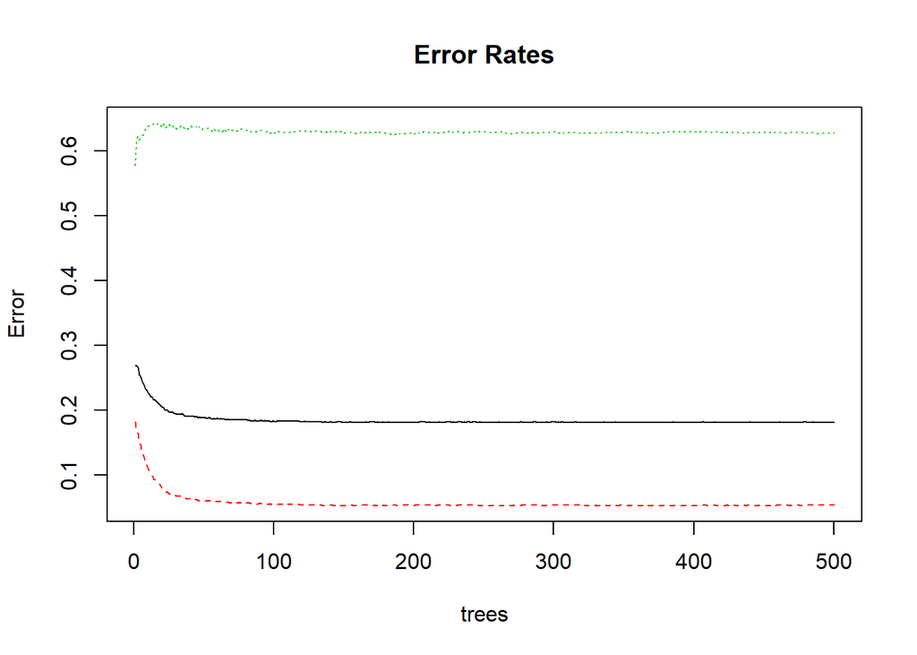

```r
plot(default_bag, main = "Error Rates")
```

- Exploremos la importancia de las variables de manera grafica

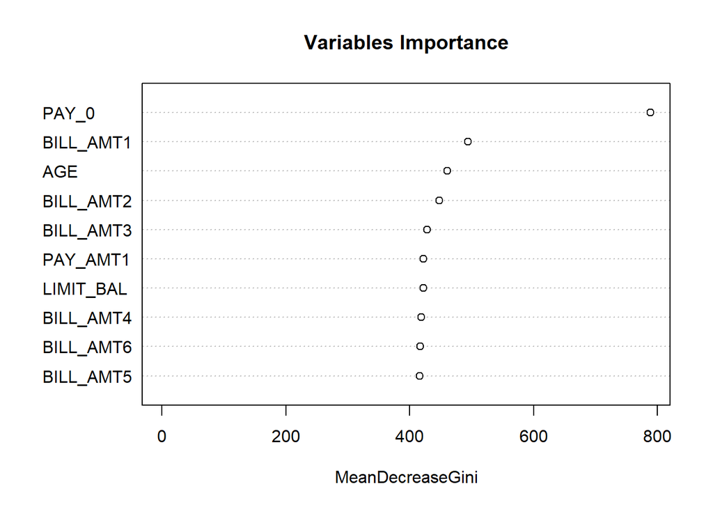

```r
varImpPlot(default_bag, sort = TRUE, main="Variables Importance",type=2, n.var=10)
```

- Encontremos las predicciones

```r
rf_pred <- predict(default_bag, default_test)
```

```r
CrossTable(default_test_labels, rf_pred, prop.chisq=FALSE, prop.c=FALSE, prop.r=FALSE, dnn=c("real", 'pronostico'))
```

```
##
##
##    Cell Contents
## |-------------------------|
## |                       N |
## |         N / Table Total |
## |-------------------------|
##
##
## Total Observations in Table:  6000
##
##
##              | pronostico
##         real |         0 |         1 | Row Total |
## -------------|-----------|-----------|-----------|
##            0 |      4443 |       268 |      4711 |
##              |     0.741 |     0.045 |           |
## -------------|-----------|-----------|-----------|
##            1 |       797 |       492 |      1289 |
##              |     0.133 |     0.082 |           |
## -------------|-----------|-----------|-----------|
## Column Total |      5240 |       760 |      6000 |
## -------------|-----------|-----------|-----------|
##
##
```

## Que modelo predice mejor?

```r
CrossTable(nb_test_pred, default_test_labels, prop.chisq=FALSE,
prop.r=FALSE, prop.c=FALSE, dnn=c('predicted', 'actual'))
```

```
##
##
##    Cell Contents
## |-------------------------|
## |                       N |
## |         N / Table Total |
## |-------------------------|
##
##
## Total Observations in Table:  6000
##
##
##              | actual
##    predicted |         0 |         1 | Row Total |
## -------------|-----------|-----------|-----------|
##            0 |      4642 |        19 |      4661 |
##              |     0.774 |     0.003 |           |
## -------------|-----------|-----------|-----------|
##            1 |        69 |      1270 |      1339 |
##              |     0.011 |     0.212 |           |
## -------------|-----------|-----------|-----------|
## Column Total |      4711 |      1289 |      6000 |
## -------------|-----------|-----------|-----------|
##
##
```

```r
CrossTable(default_test_labels, dt_pred, prop.chisq=FALSE, prop.c=FALSE, prop.r=FALSE, dnn=c("default real", 'default pronosticado'))
```

```
##
##
##    Cell Contents
## |-------------------------|
## |                       N |
## |         N / Table Total |
## |-------------------------|
##
##
## Total Observations in Table:  6000
##
##
##              | default pronosticado
## default real |         0 |         1 | Row Total |
## -------------|-----------|-----------|-----------|
##            0 |      4465 |       246 |      4711 |
##              |     0.744 |     0.041 |           |
## -------------|-----------|-----------|-----------|
##            1 |       829 |       460 |      1289 |
##              |     0.138 |     0.077 |           |
## -------------|-----------|-----------|-----------|
## Column Total |      5294 |       706 |      6000 |
## -------------|-----------|-----------|-----------|
##
##
```

```r
CrossTable(default_test_labels, rf_pred, prop.chisq=FALSE, prop.c=FALSE, prop.r=FALSE, dnn=c("real", 'pronostico'))
```

```
##
##
##    Cell Contents
## |-------------------------|
## |                       N |
## |         N / Table Total |
## |-------------------------|
##
##
## Total Observations in Table:  6000
##
##
##              | pronostico
##         real |         0 |         1 | Row Total |
## -------------|-----------|-----------|-----------|
##            0 |      4443 |       268 |      4711 |
##              |     0.741 |     0.045 |           |
## -------------|-----------|-----------|-----------|
##            1 |       797 |       492 |      1289 |
##              |     0.133 |     0.082 |           |
## -------------|-----------|-----------|-----------|
## Column Total |      5240 |       760 |      6000 |
## -------------|-----------|-----------|-----------|
##
##
```